## Part 1

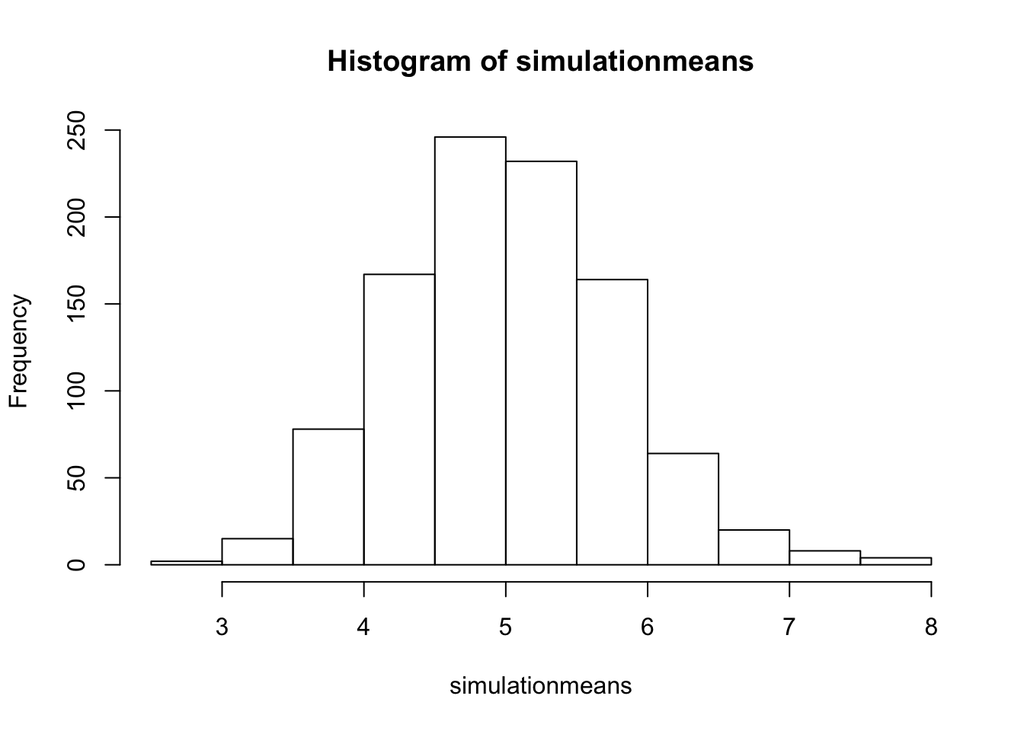

```r
## set parameters
numsim <- 1000
n <- 40
lambda <- .20
set.seed(123)

simulation1 <- matrix(rexp(numsim*n, rate = lambda), numsim)
simulationmeans <- apply(simulation1, 1, mean)

hist(simulationmeans)
```

# 1.1 Theoretical distribution vs sample distribution

now we compare the distributions of the sample mean versus the theoretical mean

```r
actual_mean <- mean(simulationmeans)
theoretical_mean <- 1/lambda
print(actual_mean)
```

```
## [1] 5.011911
```

```r
print(theoretical_mean)
```

```
## [1] 5
```

the sample mean (5.01) approximates the theoretical mean (5.0), not quite the same but almost.

# 1.2 Theoretical Variance vs Sample Variance

```r
sample_variance <- var(simulationmeans)
theoretical_variance <- (1/lambda)^2/n
print(sample_variance)
```

```
## [1] 0.6088292
```

```r
print(theoretical_variance)
```

```
## [1] 0.625
```

Again the sample mean (.608) approximates the theoretical variance ( .625)

# 1.3 demonstrate distribution approximates normal distribution

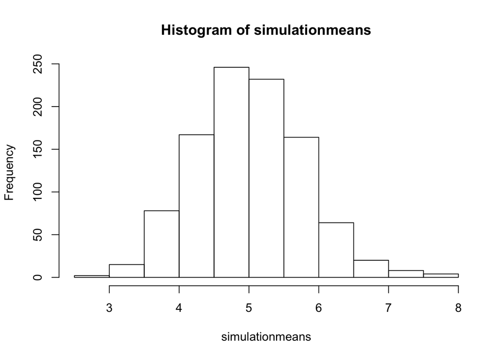

```r
hist(simulationmeans)
```

```r
shapiro.test(simulationmeans)
```

```
##
##  Shapiro-Wilk normality test
##
## data:  simulationmeans
## W = 0.99474, p-value = 0.001491
```

## Part 2 Tooth Growth Data

For the second part of the course project we are to compare the tooth growth data for two groups; groups that took ‘OJ’ supp, and another group that took ‘VC’ supp. these comparisons will be made at three seperate levels, depending on the dosage taken by the participants (.5, 1 or 2)

# Data summary regarding dosage

First we will explor the data by comparing the two seperate groups with regards to dosage

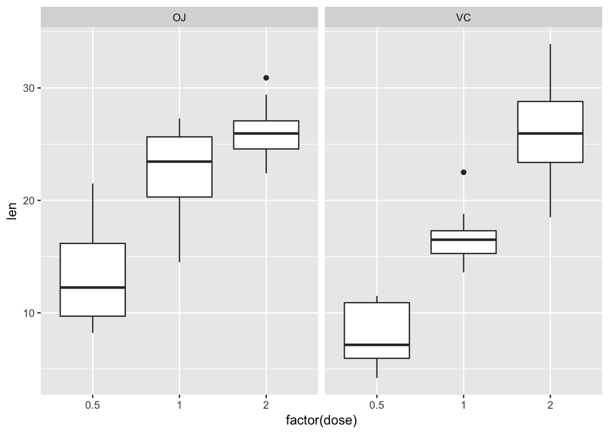

```r
library(datasets)
library(ggplot2)

g <- ggplot(ToothGrowth, aes(factor(dose), len )) +
                        geom_boxplot() + facet_grid(.~supp)
print(g)
```

there apprears to be a upwards trend in both groups as dosage increases. ‘Supp’ also seems to affect the groups differently for the first two dosages.

# Subsetting data

next we will subset our dataframe by dosage amount so we can run t-tests and compare the different groups.

```r
data(ToothGrowth)
doseGrowth1 <- subset(ToothGrowth, dose == 0.5)
doseGrowth2 <- subset(ToothGrowth, dose == 1)
doseGrowth3 <- subset(ToothGrowth, dose == 2)
```

now that we have subset our toothGrowth dataset with regards to dose, we will now conduct three tests to determine if there is a difference between ‘OJ’ and ’VC" supp groups:

test1 h0: dosegrowth1(VC) = dosegrowth1(OJ) test2 h0: dosegrowth2(VC) = dosegrowth2(OJ) test3 h0: dosegrowth3(VC) = dosegrowth3(OJ)

# Test1

```r
t.test(len~supp, data = doseGrowth1)
```

```
##
##  Welch Two Sample t-test
##
## data:  len by supp
## t = 3.1697, df = 14.969, p-value = 0.006359
## alternative hypothesis: true difference in means is not equal to 0
## 95 percent confidence interval:
##  1.719057 8.780943
## sample estimates:
## mean in group OJ mean in group VC
##            13.23             7.98
```

The results of this t-test seem to indicate for a dose of .5 there is a significant difference between the two supp groups (p<.05).

# Test2

```r
t.test(len~supp, data = doseGrowth2)
```

```
##
##  Welch Two Sample t-test
##
## data:  len by supp
## t = 4.0328, df = 15.358, p-value = 0.001038
## alternative hypothesis: true difference in means is not equal to 0
## 95 percent confidence interval:
##  2.802148 9.057852
## sample estimates:
## mean in group OJ mean in group VC
##            22.70            16.77
```

The results of this t-test seem to indicate for a dose of 1 there is a significant difference between the two supp groups (p<.05).

# Test3

```r
t.test(len~supp, data = doseGrowth3)
```

```
##
##  Welch Two Sample t-test
##
## data:  len by supp
## t = -0.046136, df = 14.04, p-value = 0.9639
## alternative hypothesis: true difference in means is not equal to 0
## 95 percent confidence interval:
##  -3.79807  3.63807
## sample estimates:
## mean in group OJ mean in group VC
##            26.06            26.14
```

for the last dosage group there does not seem to be a difference between the two groups (p>.05) therefore the null hypothesis is not rejected.